# Milestone

Benjamin Hoffner-Brodsky

4/5/2019

# Data

I sourced the data on Chinese aid flow from the AidData research team at William and Mary. The data was collected through two independent efforts. The first sought to collect data on the details of over 3,000 financial transactions between China and countries in East Asia and the Pacific. The second sought to geocode the data for each of those projects to assist with geospatial visualizations. I use both of these efforts by merging the datasets off of project codes.

So far, I have merged the data and used exploratory visualizations to get a sense for the strength of correlations present between aid funding and the various corollary variables that I’m going to be exploring. I’ve also begun to clean the data and analyze which fields have sufficient data to base models off of, and which have sufficient NA values to make further analysis not worthwhile. Finally, I’ve started to work on some of the predictive models based on the DataCamp on modeling.

# Sample Visualization

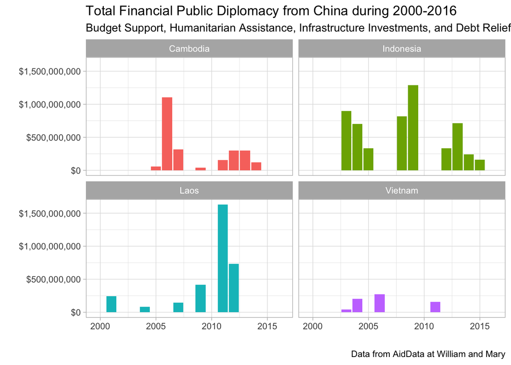